# INSIGHTS

The following insights were derived from the analysis:

- Some dogs got 0/10 rating
- Most of tweets have only one image.
- All numeric variables have right skewed distribution, that means that the least values have occurred the most.
- We have a good percentage of high prediction cases (> 0.8).
- Most of dog ratings fall between 0 and 200, and we have extreem values reached >17500.
- The only relationship we can mention here, is the strong positive correlation between the retweets count & favorite count. and that makes sense. The more images the tweet has, the more likely to get retweets & favorites.
- Twitter for iPhone is the most used application for Twitter users of WeRateDogs.
- Almost 75% of the results are True.
- Multi_stages dogs have very little percentages.
- Pupper & Doggo stages have more than 80% of the dogs.
- Most of tweets had retweets less than 10,000 and favorites up to 32,000.
- We have a few tweets that got much more favorites & retweets.
- Alwayse the favorites count is bigger than the retweets count.
- There is a slight increase in favorites & retweets overtime.
- The biggest retweet count was about 75,000 and that was in June 2016.
- The highest mean ratings are not associated to dogs at all.
- I thought that number of images would result more confident results, but that seems not to be true.
- Most of the high confidence results were based on 1 image.

# Visualizations

```python
from IPython.display import Image
```

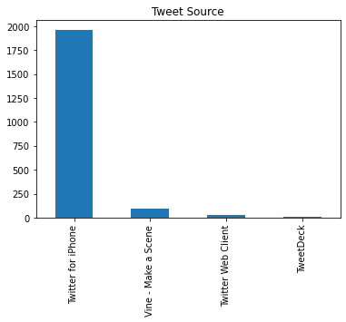

```python
Image(filename = 'first_image.png')
```

- The above figure shows that twitter for iphone is the most used app;ication for twitter user of WeRateDogs

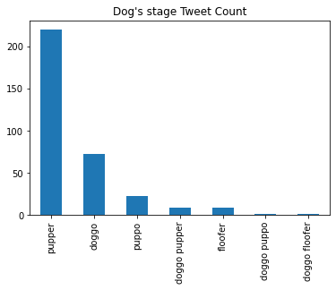

```python
Image(filename='second_image.png')
```

- This shows that the pupper is the most tweeted dog_stage for twitter users of WeRateDogs

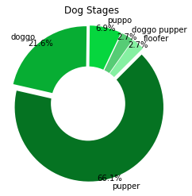

```python
Image(filename='third_image.png')
```

- Pupper and doggo stages are the most tweeted dog_stages.
- Multi-stages dogs have very little percentage of tweets

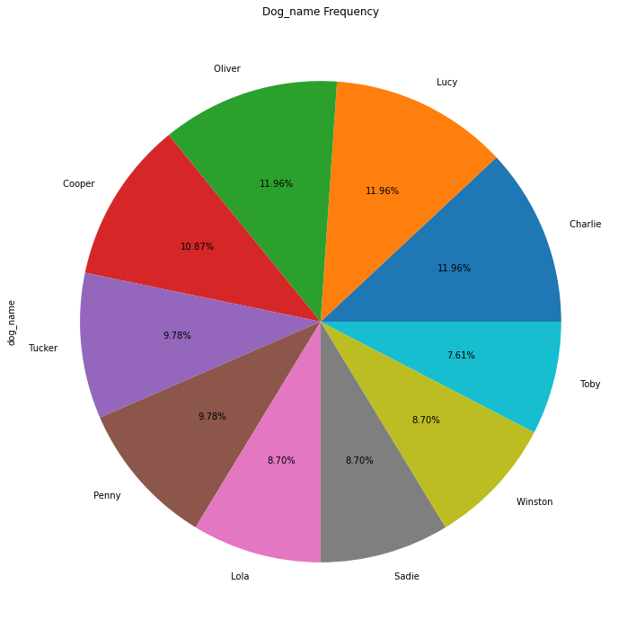

```python
Image(filename='fourth_image.png')
```

- From the figure we can see that charlie, Lucy, and Oliver are the mostly used dog names